# Homeownership and Social Reproduction

Bolun Zhang & Ke Nie

## Research Question

Does owning a house make a person capitalist? Pierre Bourdieu’s answer is a conditional yes. He asserts that in the social reproduction of class, not only the amount of capital, but also the structure of such, i.e., the composition of economic capital and cultural capital, matter. More specifically, different capital structure will bring in different strategies of social reproduction. Along this line, Bourdieu claims that homeownership represents a specific reproduction route, as he points out that house is “one of the chief means by which the domestic unit ensures that a certain transmissible heritage is accumulated and preserved” (2005:21). In this social reproduction project, house carries a meaning of “permanence”. In his observation on France, Bourdieu contends that “the structure of capital plays a determining role in the choice between purchasing and renting…it is among the categories appreciably richer in economic than cultural capital, and which depend mainly on economic capital for their reproduction, that the proportion of homeowners is highest” (ibid:26-27). On the contrary, “whereas among the fractions richer in economic than cultural capital the rate of home ownership is hardly dependent on income at all, it is closely linked to it among the fractions richer in cultural than economic capital” (ibid:28). In other words, owning a house in France means that one chooses an economically emphasized social reproduction approach.

In the preliminary research using GSS1993, we constructed several measurements of cultural capital and logistic regression to examine its relationship with homeownership. We did not find enough evidence showing that the homeownership pattern exists in contemporary American society. In this project, we delve further into the question by asking: does homeownership represent a different social reproduction approach? Framing it counter-factually, would one have different capital structure if his/her parents had made the opposite choice of homeownship when he/she was a child?

The consequences of homeownership on child generation’s outcome has been explored by different bodies of literature. One of the most common beliefs is that homeownership provides stable growing-up environment and hence leads to better educational performance (Dietz and Haurin 2003; Newman et al 1998; Zavisca and Gerber, 2016; Gibbons et al 2017). Specifically, Green and White (1997) argues that the 17-year-old children who live in an owned home are less likely to drop out of school or give birth to a baby, and Aaronson (2000) claims that the stability created by homeownership helps with children’s cognitive ability. Some other scholars also believe that children have a higher chance to own a house themselves afterwards if they lived in an owned house in their childhood (Boehm and Schlottmann 1999), unless there is easy access to homeownership (Mulder et al 2015). This implies a similar reproduction strategy among generations.

However, there are two common limitations related to this project. First, most research only talks about the influence of homeownership in specific types of capital, such as future income or educational attainment, rather than the structure of the capital, which remains unexplored. Second, most research has not successfully solved the problem of selection bias. They either ignor it, such as in Green and White’s work, or use unconvincing instrument variables like aggregation data or market price. For example, Dietz and Haurin (2002) use down payment and interest rate as instrumental variables in examing the effect of homeownership on child outcomes, but the LATE in this case would be too constrained. After all, we take the matching approach to partly solve the selection bias problem.

## The Observation Selection and Measurement

We use two datasets for this research: “Panel Study of Income Dynamics” (later as PSID) as the main data and “Pathways to Adulthood: A Three-Generation Urban Study, 1960-1994 (Baltimore)” as a supplement (later as PTA). In the PSID dataset, we selected every respondent that is a descendent of a previous surveyed core family (whose person number is smaller than 170) and whose age is between 25-28 when he/she was surveyed during 2005-2015. As the respondent has been split from the parental family and has formed a new household in any year between 2005-2015, being the head or spouse in the family, we link the respondent with his/her original family 15 years before he/she was surveyed as the child in that parental family, whose information is supported by the surveys during 1989-1999. We drop all observations that have “Not Applicable” answer in every categories. After the first round of selection, we have 1234 unique observations. We also use a similar selection method to process the data of PTA, with 1069 unique observations left for further investigation.

We create a dummy variable as the treatment to indicate whether the respondent’s parents owned the house that they lived in 15 years ago, where 1 means the parents owned the house and 0 means not. We also recode race, veteran status, and marriage status into dummy variables, where 1 respectively means white, veteran, and married, while 0 means not. In aspect of responding variable, we construct two different ones: first is the total income of the splitoff household divided by the sum of the schooling years of the head and the spouse. (If there is no spouse in the household, the schooling years of the spouse will be counted as 0); the second is a similar one, but we log the total income of the splitoff family instead and then divide it by the sum of the schooling years. Due to the missing data of the parental family wealth in some years, we use the parental family wealth data surveyed in 1989 to estimate that in 1991. Similarly, the 1994 parental family wealth data are used to estimate that in 1993 and 1995, while 1999 data are to estimate in 1997 and 1999.

## Matching

Here, we use one to one distance matching without replacement to select similar control group and treatment group. We do not use propensity matching since two cases with similar propensity score can be dramatically different, and hence might bring bias into the following analysis while using the potential outcome model. The variables we use for matching are: the schooling years of the respondent’s father; the father’s race (as non-white/white); the number of children in the parental family 15 years ago; the parental family wealth 15 years ago; the total taxable income of the parental family 15 years ago.

After the first matching, we have 804 observations left. The results are presented below. The matching is not successful, since the difference between the treatment group and the control group is still very significant.

**Table 1: First Matching - without area code**

|  | mean.Tr | mean.Co | sdiff | sdiff.pooled | var.ratio | T pval | KS pval |
| --- | --- | --- | --- | --- | --- | --- | --- |
| feduc | 13.555 | 12.025 | 65.866 | 65.866 | 1.039 | 0 | 0 |
| frace | 0.806 | 0.378 | 108.061 | 108.061 | 0.665 | 0 |  |
| nkids | 2.463 | 2.913 | -45.776 | -45.776 | 0.526 | 0 | 0 |
| pwealth | 129446.600 | 15715.770 | 39.913 | 39.913 | 8.233 | 0 | 0 |
| txincome | 48498.650 | 21991.340 | 78.182 | 78.182 | 1.605 | 0 | 0 |

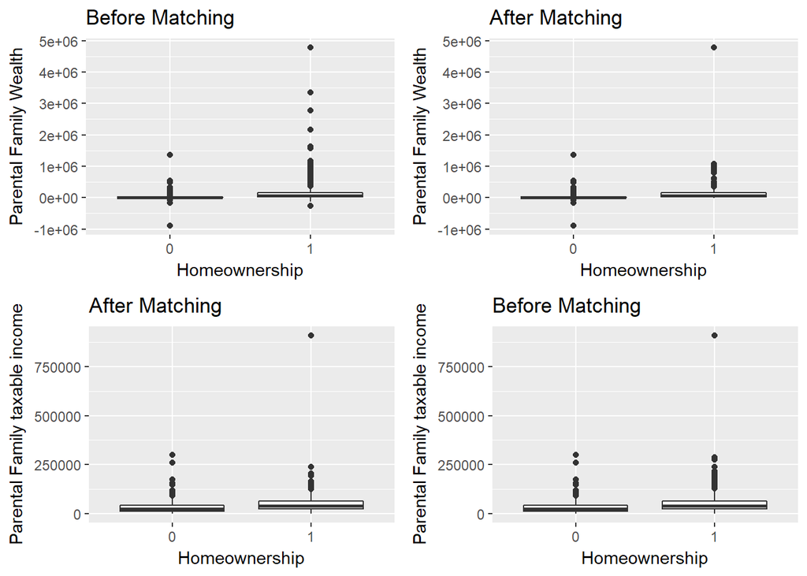

Given the results of the first matching, we decide to do blocking before matching based on where the father of the respondent was surveyed. Geographic information is important here, becasue the social space in Bourdieu’s sense is not even across different area, and hence the access to homeownership might be different. Controlling the geographic location helps us pin down this factor.

Accordingly, we tried matching the data within each area at first, and combined the results together. However, the results suggests that the selection bias has still not been solved. Therefore, we use the exact matching for area index, meaning that if the two closest observations do not have the exact area code, they will be dropped from the dataset. As a result, only those who are similar to each other the most will be selected. After this second matching, there are 196 observations left. The balance check is reported below:

**Table 2: Second Matching - with area code**

|  | mean.Tr | mean.Co | sdiff | sdiff.pooled | var.ratio | T pval | KS pval |
| --- | --- | --- | --- | --- | --- | --- | --- |
| feduc | 12.299 | 12.629 | -13.957 | -13.957 | 1.603 | 0.209 | 0.324 |
| frace | 0.495 | 0.464 | 6.154 | 6.154 | 1.005 | 0.591 |  |
| nkids | 2.691 | 2.464 | 21.511 | 21.511 | 0.860 | 0.148 | 0.272 |
| pwealth | 17416.490 | 17416.490 | 0 | 0 | 1 | 1 | 1 |
| txincome | 37731.900 | 27890.610 | 28.379 | 28.379 | 2.050 | 0.015 | 0.012 |

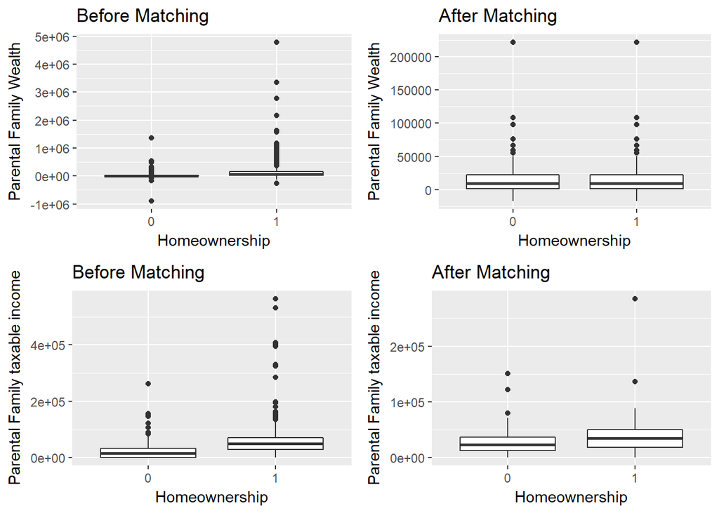

This approach also helps achieve two other important theoretical conditions. First, the difference between the schooling years of the respondent’s father and parental family wealth are controlled. This largely ensures that the respondents from the treatment group and those from the control group are having similar cultural capital and economic capital primarily. Second, the parental families in the control group and the treatment group were both having similar number of children. Thus we have better confidence to guess that their children get similar attention from their parents. Under these two conditions, we might be able to examine that whether house is a special kind of property that will lead to a social reproduction pattern emphasizing more on the economic capital.

## Supplementary data

**Table 3: Matching Result for PTA data**

|  | mean.Tr | mean.Co | sdiff | sdiff.pooled | var.ratio | T pval | KS pval |
| --- | --- | --- | --- | --- | --- | --- | --- |
| RACE | 0.195 | 0.201 | -1.466 | -1.466 | 0.978 | 0.638 |  |
| pincome2 | 7742.733 | 6936.047 | 21.259 | 21.259 | 1.119 | 0.0001 | 0.030 |
| nkids | 3.578 | 3.744 | -10.074 | -10.074 | 1.143 | 0.057 | 0.104 |
| peduc | 10.113 | 10.113 | 0 | 0 | 1 | 1 | 1 |
| SEX | 0.419 | 0.488 | -14.122 | -14.122 | 0.974 | 0.003 |  |
| poverty | 5026.023 | 5066.695 | -3.676 | -3.676 | 1.031 | 0.471 | 0.202 |
| live | 0.782 | 0.782 | 0 | 0 | 1 | 1 |  |
| neighbor | 2.529 | 2.529 | 0 | 0 | 1 | 1 | 1 |

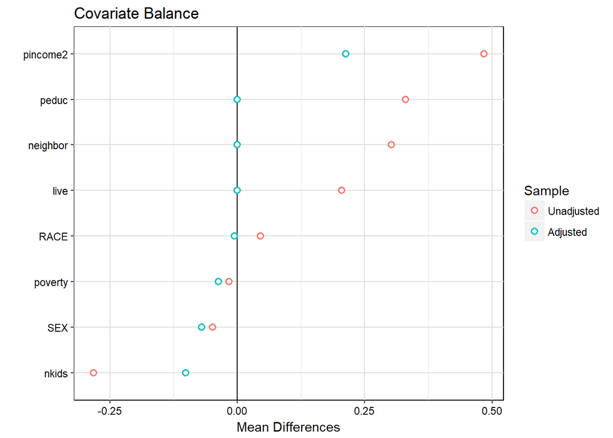

The matching results seems to be satisifying for further investigation. Therefore, we have finished setting up our datasets, and our regression models are based on these given settings.

## Result & Discussion

Our designed regression models are focusing on the effect of homeownership on capital structure. As we stated in the first section, the explanatory variable is a dummy variable indicating whether the respondent lived in a place which his parents owned when he was at 10, 11, or 12, depended on the data of the respondent. The responding variable is either the total income of the new household that the respondent has formed after grown up over the total schooling years of the respondent and his/her spouse, if possible, or the logged total income over the total schooling years. We also use the total income and total schooling years alone respectively as new models for reference. Therefore, we will have 4 models for each regression table.

The preliminary results of the regression models are reported below, where Table 4 is for the PSID data and Table 5 is for PTA. After controlling the parental wealth and taxable income by matching, the R-square for both model have been reduced. We have also checked roboust standard errors and found that they will not change the results significantly. Although the results of these two cases differ from each other, we did not find strong evidence to support Bourdieu’s theory for both case.

**Table 4: Regression Table for PSID data**

|  | **Family Income:Famlily Total Education** | **Logged Family Income:Famlily Total Education** | **Family Income** | **Education** |
| --- | --- | --- | --- | --- |
|  | **Model 1** | **Model 2** | **Model 3** | **Model 4** |
| Homeownership | -231.730 | 0.021 | -4946.056 | 0.184 |
|  | (244.301) | (0.026) | (4755.219) | (0.290) |
| Family Head Age | 29.919 | 0.008 | -1625.449 | -0.062 |
|  | (118.541) | (0.012) | (2307.357) | (0.141) |
| Parental Family Father Education | -76.966 | -0.006 | -1135.892 | 0.231*** |
|  | (62.587) | (0.007) | (1218.229) | (0.074) |
| Parental Family Mother Education | 17.380 | -0.001 | 585.649 | 0.011 |
|  | (22.898) | (0.002) | (445.695) | (0.027) |
| Parental Family Taxable Income | 0.013** | -0.00000* | 0.329*** | 0.00001 |
|  | (0.005) | (0.00000) | (0.097) | (0.00001) |
| Parental Family Wealth | -0.003 | 0.00000 | -0.059 | 0.00000 |
|  | (0.004) | (0.00000) | (0.076) | (0.00000) |
| Parental Family Kids Number | -111.931 | -0.012 | -131.236 | 0.032 |
|  | (108.171) | (0.011) | (2105.496) | (0.128) |
| Constant | 2818.552 | 0.547 | 99368.570 | 11.428*** |
|  | (3188.250) | (0.333) | (62057.940) | (3.784) |
| Omit dummies? | Yes | Yes | Yes | Yes |
| N | 194 | 194 | 194 | 194 |
| R-squared | 0.107 | 0.400 | 0.234 | 0.229 |
| Adj. R-squared | 0.021 | 0.342 | 0.160 | 0.154 |
| Residual Std. Error (df = 176) | 1555.975 | 0.163 | 30286.390 | 1.847 |
| F Statistic (df = 17; 176) | 1.244 | 6.897*** | 3.170*** | 3.074*** |
| p < .01; p < .05; p < .1 |  |  |  |  |

For PSID, after controlling the schooling years of the respondent’s father and his/her parental family wealth, we do not find evidence to support Bourdieu’s argument that the homeowneship would lead to different capital structure of the child generation. Moreover, opposite to the previous research about the effect of homeownership on child outcome, we did not find evidence that the homeownership will lead to higher education attainment or household income in the child generation in this more middle class biased sample. The result implies that homeownership as a form of economic capital might not be that different from other kinds of economic capital, which has little influence in determining the capital structure of the child generation.

**Table 5: Regression Table for PTA data**

|  | **Individual Income:Individual Education** | **Logged Individual Income:Individual Education** | **Individual Income** | **Individual Education** |
| --- | --- | --- | --- | --- |
|  | **Model 1** | **Model 2** | **Model 3** | **Model 4** |
| Homeownership | 123.766 | -0.049*** | 2856.738*** | 0.716*** |
|  | (78.711) | (0.018) | (988.669) | (0.148) |
| Race: White | 134.296 | 0.108*** | -1193.498 | -2.004*** |
|  | (153.224) | (0.035) | (1924.600) | (0.288) |
| Parental Family Income | 0.026** | 0.00000 | 0.314** | 0.00002 |
|  | (0.012) | (0.00000) | (0.149) | (0.00002) |
| Parental Family Kids Number | 47.859 | 0.012* | 404.359 | -0.056 |
|  | (30.918) | (0.007) | (388.357) | (0.058) |
| Parental Family Father Education | 50.374** | -0.002 | 856.401*** | 0.188*** |
|  | (22.021) | (0.005) | (276.603) | (0.041) |
| Sex: Male | 299.857*** | 0.062*** | 2806.209*** | -0.667*** |
|  | (78.847) | (0.018) | (990.377) | (0.148) |
| Parental Family Poverty Level | -0.092** | -0.00000 | -1.164** | -0.0001 |
|  | (0.046) | (0.00001) | (0.574) | (0.0001) |
| Live with F/M at age 7/8 | 55.136 | -0.016 | 1100.507 | 0.222 |
|  | (103.256) | (0.023) | (1296.975) | (0.194) |
| Constant | 536.941 | 0.728*** | 5289.739 | 11.002*** |
|  | (331.636) | (0.075) | (4165.597) | (0.623) |
| N | 688 | 688 | 688 | 688 |
| R-squared | 0.063 | 0.062 | 0.068 | 0.217 |
| Adj. R-squared | 0.046 | 0.046 | 0.051 | 0.203 |
| Residual Std. Error (df = 675) | 1021.878 | 0.231 | 12835.540 | 1.921 |
| F Statistic (df = 12; 675) | 3.770*** | 3.739*** | 4.085*** | 15.601*** |
| p < .01; p < .05; p < .1 |  |  |  |  |

The PTA results are not against the statement that owning a house has a positive effect on the child generation’s income and education attainment, at least for the poor income population. A stable homeownership might be crucial for the next generation to achieve upward mobilization, even when the total wealth of the parents were similar. However, the increase in the next generation’s income and education attainment with the homeownership is somehow at such a similar pace so that we do not find evidence for the homeownership’s predisposition to a higher proportion of economic capital compared to cultural capital. If we use the logged income divided by schooling year as the responding variable, the coefficient is even negative. This might be based on the fact that the cultural capital and economic captial were both limited for most poor-income families. For some families, homeownership might stimulate the accumulation of cultural capital (such as higher education attainment). Thus, a stable route of social reproduction, like what captured by the homeownership, is more important in these families than that in the middle class families.

## Conclusion

Different people have different issues with whether owning a house. But for Bourdieu, it is about social reproduction. However, our investigation on PSID panel data as well as PTA regional data does not support his idea of the impact of homeownerhip on child generation’s capital structure, meaning that homeownership might not be a special incentive for the accumulation in economic capital compared to cultural capital in the future. Nevertheless, this conclusion might be weakened by the fact that the selection bias in our data cannot be fully solved. Specifically, we argue that there is no treatment effect of homeownership on future capital for middle class families in the US, and there might be some effect for low income families in Baltimore, while we cannot say more about other groups in the US confidently.

Although Bourdieu himself confessed that his theory might not be applicable in other countries and regions, his theoretical framework has been widely used for understanding the social reproduction in different societies. While some of his theory cannot be supported by empirical data, as the case here, his idea of capital structure still matters in terms of analyzing social reproduction and stratification. We suggest that future research on this topic could come up with a better solution to reduce the selection bias and hence yield more accurate results of testing the treatment effect of homeownership.

## Bibliography

- Aaronson, D. (2000). A Note on the Benefits of Homeownership. *Journal of Urban Economics*, 47(3), 356-369.
- Boehm, T. P., & Schlottmann, A. M. (1999). Does home ownership by parents have an economic impact on their children?. *Journal of Housing Economics*, 8(3), 217-232.
- Bourdieu, P. (2005). *The social structures of the economy*. Polity.
- Dietz, R. D., & Haurin, D. R. (2003). The social and private micro-level consequences of homeownership. *Journal of urban Economics*, 54(3), 401-450.
- Gibbons, S., Silva, O., & Weinhardt, F. (2017). Neighbourhood turnover and teenage attainment. *Journal of the European Economic Association*, 15(4), 746-783.
- Green, R. K., & White, M. J. (1997). Measuring the benefits of homeowning: Effects on children. *Journal of urban economics*, 41(3), 441-461.
- Haurin, D. R., Parcel, T. L., & Haurin, R. J. (2002). Does homeownership affect child outcomes?. *Real Estate Economics*, 30(4), 635-666.
- Mulder, C. H., Dewilde, C., van Duijn, M., & Smits, A. (2015). The association between parents’ and adult children’s homeownership: A comparative analysis. *European Journal of Population*, 31(5), 495-527.
- Newman, S., Harkness, J., & Yeung, W. J. J. (1998, May). Neighborhood poverty, assisted housing, and the educational attainment of children. In *mid-year meeting of the American Real Estate and Urban Economics Association* (pp. 23-24).
- Zavisca, J. R., & Gerber, T. P. (2016). The socioeconomic, demographic, and political effects of housing in comparative perspective. *Annual Review of Sociology*, 42, 347-367.